# Goal

# Task 4: Feature Engineering.

> If we would like to predict the house sale price.

> Analyze the scale of each attribute and determine which ones you would transfer `(e.g., cateogorical features)`.

> Discuss how you plan to select important features.

## Machine Learning Part

> This is what my modelling part looks like so far:

> > 1. Modelling

> > 2.Predictions and evaluation

> > 3.Feature Engineering

> > 4.Compare results

## 1. Modelling

> For the modelling part, I'm going to use pipelines. Pipelines are a simple way to keep your preprocessing and modelling code organized.

> These are the steps that I'm taking for building a machine learning model:
> - Splitting the data
> - Using OneHotEncoding to transform the categorical features into numerical values
> - Using ColumnTransformer to bundle the different preprocessing steps
> - Instantiate a model
> - Bundle the preprocessing and model code in a pipeline

### Convert all categorical columns to numerical

```python
encoder = LabelEncoder()
df['NEIGHBORHOOD'] = encoder.fit_transform(df['NEIGHBORHOOD'])

encoder = TargetEncoder()
df['BUILDING CLASS CATEGORY'] = encoder.fit_transform(df['BUILDING CLASS CATEGORY'], df['SALE PRICE'])

encoder = TargetEncoder()
df['BUILDING CLASS AT TIME OF SALE'] = encoder.fit_transform(df['BUILDING CLASS AT TIME OF SALE'], df['SALE PRICE'])
```

> It is possible to drop `address` column because the `zip code` column provides us with the same information

```python
df.drop(['ADDRESS'], axis = 1, inplace = True)
df.drop(['SALE DATE'], axis = 1, inplace = True)
```

```python
df
```

|  | BOROUGH | NEIGHBORHOOD | BUILDING CLASS CATEGORY | BLOCK | LOT | ZIP CODE | RESIDENTIAL UNITS | COMMERCIAL UNITS | TOTAL UNITS | LAND SQUARE FEET | GROSS SQUARE FEET | YEAR BUILT | TAX CLASS AT TIME OF SALE | BUILDING CLASS AT TIME OF SALE | SALE PRICE | YEAR SOLD | MONTH SOLD | BUILDING AGE |
| --- | --- | --- | --- | --- | --- | --- | --- | --- | --- | --- | --- | --- | --- | --- | --- | --- | --- | --- |
| 149400 | 1.0 | 228 | 495257.630084 | 1495.0 | 4.0 | 10028.0 | 0.0 | 0.0 | 0.0 | 0.0 | 0.0 | 1955 | 2.0 | 490110.413240 | 0 | 2018 | 7 | 67 |
| 43413 | 1.0 | 228 | 438608.165499 | 1543.0 | 151.0 | 10028.0 | 1.0 | 1.0 | 2.0 | 1228.0 | 1826.0 | 1900 | 4.0 | 392324.393519 | 0 | 2020 | 3 | 122 |
| 43383 | 1.0 | 228 | 425834.496224 | 1494.0 | 125.0 | 10028.0 | 1.0 | 4.0 | 5.0 | 1635.0 | 6418.0 | 1899 | 2.0 | 388514.946565 | 0 | 2020 | 12 | 123 |
| 43465 | 1.0 | 230 | 414913.772409 | 1150.0 | 23.0 | 10024.0 | 1.0 | 0.0 | 1.0 | 1737.0 | 3700.0 | 1901 | 1.0 | 413881.298182 | 0 | 2020 | 1 | 121 |
| 43433 | 1.0 | 229 | 375595.008716 | 1610.0 | 57.0 | 10029.0 | 8.0 | 1.0 | 9.0 | 1750.0 | 6800.0 | 1910 | 2.0 | 185190.356643 | 0 | 2020 | 9 | 112 |
| ... | ... | ... | ... | ... | ... | ... | ... | ... | ... | ... | ... | ... | ... | ... | ... | ... | ... | ... |
| 56385 | 5.0 | 167 | 414913.772409 | 2381.0 | 106.0 | 10314.0 | 1.0 | 0.0 | 1.0 | 1600.0 | 1140.0 | 1995 | 1.0 | 388077.068530 | 450000 | 2019 | 8 | 27 |
| 56386 | 5.0 | 167 | 414913.772409 | 2381.0 | 108.0 | 10314.0 | 1.0 | 0.0 | 1.0 | 1600.0 | 1140.0 | 1995 | 1.0 | 388077.068530 | 500000 | 2019 | 9 | 27 |
| 56387 | 5.0 | 167 | 414913.772409 | 2382.0 | 3.0 | 10314.0 | 1.0 | 0.0 | 1.0 | 2345.0 | 1200.0 | 1995 | 1.0 | 388077.068530 | 595000 | 2019 | 4 | 27 |
| 56376 | 5.0 | 167 | 414913.772409 | 2377.0 | 14.0 | 10314.0 | 1.0 | 0.0 | 1.0 | 2200.0 | 1624.0 | 1980 | 1.0 | 388077.068530 | 618500 | 2019 | 2 | 42 |
| 0 | 5.0 | 2 | 414913.772409 | 5404.0 | 46.0 | 10312.0 | 1.0 | 0.0 | 1.0 | 8000.0 | 3660.0 | 1998 | 1.0 | 421569.026366 | 315000 | 2020 | 10 | 24 |

166644 rows × 18 columns

```python
#normalize the data values
std_scaler = StandardScaler()

df_scaled = std_scaler.fit_transform(df.to_numpy())
df = pd.DataFrame(df_scaled, columns=list(df.columns))

print("Scaled Dataset Using StandardScaler")
df.head()
```

```
Scaled Dataset Using StandardScaler
```

|  | BOROUGH | NEIGHBORHOOD | BUILDING CLASS CATEGORY | BLOCK | LOT | ZIP CODE | RESIDENTIAL UNITS | COMMERCIAL UNITS | TOTAL UNITS | LAND SQUARE FEET | GROSS SQUARE FEET | YEAR BUILT | TAX CLASS AT TIME OF SALE | BUILDING CLASS AT TIME OF SALE | SALE PRICE | YEAR SOLD | MONTH SOLD | BUILDING AGE |
| --- | --- | --- | --- | --- | --- | --- | --- | --- | --- | --- | --- | --- | --- | --- | --- | --- | --- | --- |
| 0 | -1.981278 | 1.386932 | 0.427333 | -0.945200 | -0.486662 | -1.734589 | -0.666602 | -0.144019 | -0.672612 | -0.074208 | -0.138476 | 0.103515 | 0.750772 | 0.322724 | -0.93291 | -1.021210 | 0.145386 | -0.103515 |
| 1 | -1.981278 | 1.386932 | -0.168806 | -0.932369 | -0.218513 | -1.734589 | -0.249989 | 1.008494 | 0.107222 | -0.051718 | -0.024918 | -1.428373 | 3.386283 | -0.568593 | -0.93291 | 1.585652 | -1.017300 | 1.428373 |
| 2 | -1.981278 | 1.386932 | -0.303227 | -0.945467 | -0.265940 | -1.734589 | -0.249989 | 4.466034 | 1.276974 | -0.044265 | 0.260658 | -1.456225 | 0.750772 | -0.603316 | -0.93291 | 1.585652 | 1.598744 | 1.456225 |
| 3 | -1.981278 | 1.413754 | -0.418150 | -1.037422 | -0.452003 | -1.742136 | -0.249989 | -0.144019 | -0.282695 | -0.042397 | 0.091626 | -1.400520 | -0.566983 | -0.372103 | -0.93291 | 1.585652 | -1.598643 | 1.400520 |
| 4 | -1.981278 | 1.400343 | -0.831913 | -0.914459 | -0.389982 | -1.732702 | 2.666299 | 1.008494 | 2.836644 | -0.042159 | 0.284415 | -1.149848 | 0.750772 | -2.456615 | -0.93291 | 1.585652 | 0.726729 | 1.149848 |

```python
# Creating a copy of the  merged dataframe
copy = df
# Splitting the data into X &y
X = copy.drop(['SALE PRICE'], axis=1) # Dropping some irrelevant columns and the target
y = copy['SALE PRICE']
```

> - 70% for training
> - 15% for evaluation
> - 15% for testing

```python
#  I'm dividing the data into train, validation en test.
X_train, X_test, y_train, y_test = train_test_split(X, y, test_size=0.15, random_state=1) # 15% for test data

X_train, X_val, y_train, y_val = train_test_split(X_train, y_train, test_size=0.175, random_state=1) # ~15% for validation data
```

```python
# Selecting categorical columns
categorical_cols = [cname for cname in X_train.columns if X_train[cname].dtype == "object"]

# Select numerical columns
numerical_cols = [cname for cname in X_train.columns if X_train[cname].dtype  == 'float64']

# Keep selected columns only
my_cols = categorical_cols + numerical_cols
X_train = X_train[my_cols].copy()
X_val = X_val[my_cols].copy()
X_test = X_test[my_cols].copy()
```

```python
# Preprocessing the numerical data
numerical_transformer = SimpleImputer(strategy='median')

# Preprocessing the categorical data
categorical_transformer = Pipeline(steps=[('onehot', OneHotEncoder(handle_unknown='ignore'))])

# Bundle the preprocessing steps using ColumnTransformer
preprocessor = ColumnTransformer(transformers=[('num', numerical_transformer, numerical_cols),('cat', categorical_transformer, categorical_cols)])
```

## 2. Predictions and evaluation

> For the predictions and evaluation part of this project I'm using the Random Forest Regressor.
> - **Mean Absolute Error (MAE):** Every residual (distance between fitted line and observation) needs to be calculated for every data point, taking only the absolute value of each. Then the average of the residuals is the MAE.
> - **Mean Squared Error (MSE)** The MSE is just like the MAE, but squares the difference before summing them all instead of using the absolute value. MSE is more popular because it punishes larger which tend to be useful in the real world.
> - **R2:** In regression, R2 a statistical measure of how well the regression predictions approximate the real data points.

```python
# Building the evaluation function
def show_scores(model):
  # Bundle the transformer and the model together
  my_pipeline = Pipeline(steps=[('preprocessor', preprocessor), ('model', model)])
  # Fitting the data
  my_pipeline.fit(X_train, y_train)

  # Creating predictions for both train and test
  train_preds = my_pipeline.predict(X_train)
  val_preds = my_pipeline.predict(X_val)

  # Use the metrics to evaluate on train and test
  scores = {'Training MAE': mean_absolute_error(y_train, train_preds), 'Validation MAE': mean_absolute_error(y_val, val_preds),
            'Training MSE': mean_squared_error(y_train, train_preds), 'Validation MSE': mean_squared_error(y_val, val_preds),
            'Training R2': r2_score(y_train, train_preds), 'Validation R2': r2_score(y_val, val_preds)}

  sns.scatterplot(y_val, val_preds)
  #sns.distplot((y_val - val_preds))

  return scores
```

#### 2.1 Baseline Random Forest

```
CPU times: user 1min 47s, sys: 730 ms, total: 1min 48s
Wall time: 1min 53s
```

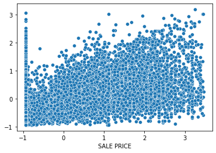

```python
%%time
model1 = show_scores(RandomForestRegressor(random_state=1))
```

## 3. Feature Engineering

> To improve my model's performance, I'm going to use feature engineering. Feature engineering is the process of creating new features that didn't exist before to improve my models predicting performance.
> 1. **Mathematical transforms:** Using arithmetic operations to create new numerical features.
> 2. **Group Transforms:** Groups transforms aggregate information across multiple rows grouped by some category.

> Features I'm thinking about:
> - Price per land square feet
> - Price per gross square feet
> - Median sale price per neighboorhood
> - Median sale price per borough
> - Median sale price per zipcode

```python
# Creating a new data frame for feature engineering
fe = df.copy()

# Mathematical transformation
fe['PRICE PER LAND SQFT'] = fe['SALE PRICE'] / fe['LAND SQUARE FEET'] # Ratio price per land square feet
fe['PRICE PER GROSS SQFT'] = fe['SALE PRICE'] / fe['GROSS SQUARE FEET'] # Ratio per gross square feet

# Group Transforms
fe['MEDIAN SALE PRICE NEIGHBORHOOD'] = fe.groupby('NEIGHBORHOOD')['SALE PRICE'].transform('median') # Median sale price per neighborhood
fe['MEDIAN SALE PRICE BOROUGH'] = fe.groupby('BOROUGH')['SALE PRICE'].transform('median') # Median sale price per borough
fe['MEDIAN SALE PRICE ZIP CODE'] = fe.groupby('ZIP CODE')['SALE PRICE'].transform('median') # Median sale price per zipcode
```

```python
fe.info()
```

```
<class 'pandas.core.frame.DataFrame'>
RangeIndex: 166644 entries, 0 to 166643
Data columns (total 23 columns):
 #   Column                          Non-Null Count   Dtype
---  ------                          --------------   -----
 0   BOROUGH                         166644 non-null  float64
 1   NEIGHBORHOOD                    166644 non-null  float64
 2   BUILDING CLASS CATEGORY         166644 non-null  float64
 3   BLOCK                           166644 non-null  float64
 4   LOT                             166644 non-null  float64
 5   ZIP CODE                        166644 non-null  float64
 6   RESIDENTIAL UNITS               166644 non-null  float64
 7   COMMERCIAL UNITS                166644 non-null  float64
 8   TOTAL UNITS                     166644 non-null  float64
 9   LAND SQUARE FEET                166644 non-null  float64
 10  GROSS SQUARE FEET               166644 non-null  float64
 11  YEAR BUILT                      166644 non-null  float64
 12  TAX CLASS AT TIME OF SALE       166644 non-null  float64
 13  BUILDING CLASS AT TIME OF SALE  166644 non-null  float64
 14  SALE PRICE                      166644 non-null  float64
 15  YEAR SOLD                       166644 non-null  float64
 16  MONTH SOLD                      166644 non-null  float64
 17  BUILDING AGE                    166644 non-null  float64
 18  PRICE PER LAND SQFT             166644 non-null  float64
 19  PRICE PER GROSS SQFT            166644 non-null  float64
 20  MEDIAN SALE PRICE NEIGHBORHOOD  166644 non-null  float64
 21  MEDIAN SALE PRICE BOROUGH       166644 non-null  float64
 22  MEDIAN SALE PRICE ZIP CODE      166644 non-null  float64
dtypes: float64(23)
memory usage: 29.2 MB
```

## Modelling again

```
CPU times: user 2min 6s, sys: 435 ms, total: 2min 7s
Wall time: 2min 13s
```

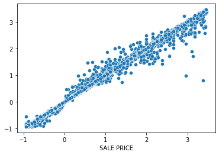

```python
%%time
model2 = show_scores(RandomForestRegressor(random_state=1))
```

## 4. Compare results

> To compare the results, I'm taking a look at the performance on the validation data. The reason for doing this is because my model hasn't seen this data and which is very important to create reliable results on data it hasn't seen before.

```python
print(model1)
print(model2)
```

```
{'Training MAE': 0.2716913342220143, 'Validation MAE': 0.7201068560323264, 'Training MSE': 0.12585294746536316, 'Validation MSE': 0.8470886612722077, 'Training R2': 0.8740569158004525, 'Validation R2': 0.1518230006467457}
{'Training MAE': 0.003725426429280567, 'Validation MAE': 0.009803250440697278, 'Training MSE': 0.00033488153963063784, 'Validation MSE': 0.0025050677540912935, 'Training R2': 0.9996648786159403, 'Validation R2': 0.99749171373909}
```

> As you can see, the results are very different. The first model that received the normal data without the extra features and performed much worse in comparison with the model that got the extra features. Due feature engineering, the R2 on `model 2` improved to reach `0.99%` on training and `0.997%` on teh validation data set.

> One last thing I would like to see if which features were imporant and decisive.

> I'm using a the library `eli5` to figure that out.

> Because I trained my models normally in the function above, I have to use some code outside the function before I can look into the feature importance.

```python
# Creating a list where I'm putting the features from the onehotencoder and numerical together
numeric_features_list = list(numerical_cols)

eli5.explain_weights(my_pipeline.named_steps['model'], top=10, feature_names=numeric_features_list)
```

| Weight | Feature |
| --- | --- |
| 0.5453 ± 0.0113 | PRICE PER LAND SQFT |
| 0.3844 ± 0.0107 | LAND SQUARE FEET |
| 0.0287 ± 0.0078 | PRICE PER GROSS SQFT |
| 0.0213 ± 0.0094 | GROSS SQUARE FEET |
| 0.0071 ± 0.0091 | MEDIAN SALE PRICE BOROUGH |
| 0.0048 ± 0.0015 | TAX CLASS AT TIME OF SALE |
| 0.0026 ± 0.0013 | ZIP CODE |
| 0.0024 ± 0.0014 | BLOCK |
| 0.0005 ± 0.0007 | MEDIAN SALE PRICE NEIGHBORHOOD |
| 0.0005 ± 0.0006 | MEDIAN SALE PRICE ZIP CODE |
| *… 12 more …* |  |

```python
numeric_features_list
```

```
['BOROUGH',
 'NEIGHBORHOOD',
 'BUILDING CLASS CATEGORY',
 'BLOCK',
 'LOT',
 'ZIP CODE',
 'RESIDENTIAL UNITS',
 'COMMERCIAL UNITS',
 'TOTAL UNITS',
 'LAND SQUARE FEET',
 'GROSS SQUARE FEET',
 'YEAR BUILT',
 'TAX CLASS AT TIME OF SALE',
 'BUILDING CLASS AT TIME OF SALE',
 'YEAR SOLD',
 'MONTH SOLD',
 'BUILDING AGE',
 'PRICE PER LAND SQFT',
 'PRICE PER GROSS SQFT',
 'MEDIAN SALE PRICE NEIGHBORHOOD',
 'MEDIAN SALE PRICE BOROUGH',
 'MEDIAN SALE PRICE ZIP CODE']
```

> As you can see, there are `3 features` in the `top 5` that were custom made by using feature engineering.

> The first one which was also made by doing feature engineering was the most relevant feature for predicting property prices in NYC.

> Overall in the top 5 ,those features were custom made.

## Task 5: AutoML

> Using Auto-sklearn to explore performance of one state-of-the-art autoML tool on the given data (after your previous preprocessing).

> Optional: compare with performing autosklearn on raw data. ref.

> [source](https://automl.github.io/auto-sklearn/master/examples/20_basic/example_regression.html)

```python
#test the accuracy of model on training set
print('The Train Score is : ' , automl.score(X_train, y_train))
```

```
The Train Score is :  0.9993381418431362
```

```python
# compute the MSE on test data
predictions = automl.predict(X_test)
print('MAE:',sklearn.metrics.mean_absolute_error(y_test,predictions))
print('MSE:',sklearn.metrics.mean_squared_error(y_test,predictions))
print('RMSE:',np.sqrt(sklearn.metrics.mean_squared_error(y_test,predictions)))
print('R^2 =',sklearn.metrics.explained_variance_score(y_test,predictions))
```

```
MAE: 0.014314162331021143
MSE: 0.0025941741335153957
RMSE: 0.0509330357775324
R^2 = 0.9974180005492962
```

> As you can see, the results are similar to each other spechaily the result of `R^2`.

> Due feature engineering, the R2 on this model improved to reach `0.99%` .

### Random Forest Model

```python
#test the accuracy of model on training set
print('RandomForestRegressor Train Score is : ' , model_imp.score(X_train, y_train))
```

```
RandomForestRegressor Train Score is :  0.9996773276620606
```

```python
y_pred = model_imp.predict(X_test)
print('MAE:',sklearn.metrics.mean_absolute_error(y_test,predictions))
print('MSE:',sklearn.metrics.mean_squared_error(y_test,predictions))
print('RMSE:',np.sqrt(sklearn.metrics.mean_squared_error(y_test,predictions)))
print('R^2 =',sklearn.metrics.explained_variance_score(y_test,predictions))
```

```
MAE: 0.014314162331021143
MSE: 0.0025941741335153957
RMSE: 0.0509330357775324
R^2 = 0.9974180005492962
```

### LR MODEL

```python
#test the accuracy of model on training set
print('linear regression Train Score is : ' , regressor.score(X_train, y_train))
```

```
linear regression Train Score is :  0.09123561029779526
```

```python
#make data prediction
yPred = regressor.predict(X_test)
```

```python
print('MAE:',sklearn.metrics.mean_absolute_error(y_test,yPred))
print('MSE:',sklearn.metrics.mean_squared_error(y_test,yPred))
print('RMSE:',np.sqrt(sklearn.metrics.mean_squared_error(y_test,yPred)))
print('R^2 =',sklearn.metrics.explained_variance_score(y_test,yPred))
```

```
MAE: 0.7712368410191223
MSE: 0.9184808185890951
RMSE: 0.9583740494134297
R^2 = 0.0857409712670133
```

### Knn MODEL

```python
#test the accuracy of model on training set
print('KNN regression Train Score is : ' , knn.score(X_train, y_train))
```

```
KNN regression Train Score is :  0.8041082049591569
```

```python
#make data prediction
yPred = knn.predict(X_test)
```

```python
print('MAE:',sklearn.metrics.mean_absolute_error(y_test,yPred))
print('MSE:',sklearn.metrics.mean_squared_error(y_test,yPred))
print('RMSE:',np.sqrt(sklearn.metrics.mean_squared_error(y_test,yPred)))
print('R^2 =',sklearn.metrics.explained_variance_score(y_test,yPred))
```

```
MAE: 0.24364197337416682
MSE: 0.31033188591220845
RMSE: 0.557074398902165
R^2 = 0.691465512957057
```

### SVR MODEL

```python
#test the accuracy of model on training set
print('SVR regression Train Score is : ' , svr.score(X_train, y_train))
```

```
SVR regression Train Score is :  0.11400517760227757
```

```python
#make data prediction
yPred = svr.predict(X_test)
```

```python
print('MAE:',sklearn.metrics.mean_absolute_error(y_test,yPred))
print('MSE:',sklearn.metrics.mean_squared_error(y_test,yPred))
print('RMSE:',np.sqrt(sklearn.metrics.mean_squared_error(y_test,yPred)))
print('R^2 =',sklearn.metrics.explained_variance_score(y_test,yPred))
```

```
MAE: 0.6495899453246222
MSE: 0.9017456860524341
RMSE: 0.9496029096693176
R^2 = 0.10998451751217997
```

### DecisionTreeRegressor MODEL

```python
#test the accuracy of model on training set
print('DT regression Train Score is : ' , dt.score(X_train, y_train))
```

```
DT regression Train Score is :  1.0
```

```python
#make data prediction
yPred = dt.predict(X_test)
```

```python
print('MAE:',sklearn.metrics.mean_absolute_error(y_test,yPred))
print('MSE:',sklearn.metrics.mean_squared_error(y_test,yPred))
print('RMSE:',np.sqrt(sklearn.metrics.mean_squared_error(y_test,yPred)))
print('R^2 =',sklearn.metrics.explained_variance_score(y_test,yPred))
```

```
MAE: 0.016978341232257412
MSE: 0.0067134213360970614
RMSE: 0.08193547056127194
R^2 = 0.9933174104832382
```

### GBM MODEL

```python
#test the accuracy of model on training set
print('GBM regression Train Score is : ' , gbm.score(X_train, y_train))
```

```
GBM regression Train Score is :  0.9694487622439207
```

```python
#make data prediction
yPred = gbm.predict(X_test)
```

```python
print('MAE:',sklearn.metrics.mean_absolute_error(y_test,yPred))
print('MSE:',sklearn.metrics.mean_squared_error(y_test,yPred))
print('RMSE:',np.sqrt(sklearn.metrics.mean_squared_error(y_test,yPred)))
print('R^2 =',sklearn.metrics.explained_variance_score(y_test,yPred))
```

```
MAE: 0.10081968853517023
MSE: 0.0331400531922917
RMSE: 0.18204409683450792
R^2 = 0.9670170119876785
```

### AdaBoostRegressor MODEL

```python
#test the accuracy of model on training set
print('AdaBoostRegressor Train Score is : ' , ada.score(X_train, y_train))
```

```
AdaBoostRegressor Train Score is :  0.7150636470424645
```

```python
#make data prediction
yPred = ada.predict(X_test)
```

```python
print('MAE:',sklearn.metrics.mean_absolute_error(y_test,yPred))
print('MSE:',sklearn.metrics.mean_squared_error(y_test,yPred))
print('RMSE:',np.sqrt(sklearn.metrics.mean_squared_error(y_test,yPred)))
print('R^2 =',sklearn.metrics.explained_variance_score(y_test,yPred))
```

```
MAE: 0.45192107143802135
MSE: 0.2837235881337526
RMSE: 0.5326571018335835
R^2 = 0.8237202114061823
```

### XGB MODEL

```python
#test the accuracy of model on training set
print('XGB regression Train Score is : ' , xgb.score(X_train, y_train))
```

```
XGB regression Train Score is :  0.9696297812764568
```

```python
#make data prediction
yPred = xgb.predict(X_test)
```

```python
print('MAE:',sklearn.metrics.mean_absolute_error(y_test,yPred))
print('MSE:',sklearn.metrics.mean_squared_error(y_test,yPred))
print('RMSE:',np.sqrt(sklearn.metrics.mean_squared_error(y_test,yPred)))
print('R^2 =',sklearn.metrics.explained_variance_score(y_test,yPred))
```

```
MAE: 0.09962881509550142
MSE: 0.033024794891340206
RMSE: 0.181727254123701
R^2 = 0.9671303292195892
```

# **Resources.**

There are a lot of resources, but these are among the most important sources that helped me and I learned from them.

**Note:** The code sources were mentioned to each cell separately.

> [statistical-hypothesis-testing-python-implementation](https://www.section.io/engineering-education/statistical-hypothesis-testing-python-implementation/)

> [statistical-hypothesis-tests-in-python-cheat-sheet](https://machinelearningmastery.com/statistical-hypothesis-tests-in-python-cheat-sheet/)

> nyc-property-sales

> [house-prices-advanced-regression-techniques](https://www.kaggle.com/competitions/house-prices-advanced-regression-techniques/code)

> new-york-city-airbnb-open-data